# Week6 Project2 - Tyding and Transfroming Three Datasets

humbertohp

October 6, 2018

## Fruits & Vegetables Prices and Calorie Guidelines

#### How much do fruits and vegetables cost? Economic Research Service estimated average prices for over 150 commonly consumed fresh and processed fruits and vegetables. Reported estimates include each product’s average retail price per pound and per edible cup equivalent (the unit of measurement for Federal recommendations for fruit and vegetable consumption). For many fruits and vegetables, a 1-cup equivalent equals the weight of enough edible food to fill a measuring cup. ERS calculated average prices at retail stores using 2013 and 2016 retail scanner data from Information Resources, Inc. (IRI). A selection of retail establishments-grocery stores, supermarkets, supercenters, convenience stores, drug stores, and liquor stores-across the U.S. provides IRI with weekly retail sales data (revenue and quantity).

#### ERS reports average prices per edible cup equivalent to inform policymakers and nutritionists about how much money it costs Americans to eat a sufficient quantity and variety of fruits and vegetables. Every five years the Departments of Agriculture and Health and Human Services release a new version of the Dietary Guidelines for Americans with information about how individuals can achieve a healthy diet. However, the average American falls short in meeting these recommendations. Many people consume too many calories from refined grains, solid fats, and added sugars, and do not eat enough whole grains, fruits, and vegetables.

#### Are food prices a barrier to eating a healthy diet? ERS research using this data set shows that, in 2013, it was possible for a person on a 2,000-calorie diet to eat a sufficient quantity and variety of fruits and vegetables for about $2.10 to $2.60 per day. The report also illustrates the variety of fruits and vegetables affordable to a family on a limited budget

### Analysis of the Impact on Food Caloric Intake and Costs of substituting certain groups of Snacks with certain categories of Fruits & Vegetables

### Installing and Loading necessary packages

```r
#install.packages("dplyr")
#install.packages("tidyr")
#install.packages("readxl")
library(dplyr)
```

```r
library(tidyr)
library(stringr)
library(readxl)
library(ggplot2)
```

## 1st Data set - Calorie Intake Impact on Snack Substitution

### Load data set (CSV) into R

#### Download target file locally from github “caloricimpacts (untidy dataset).xls”

```r
setwd("C:/DATA/HHP/Personal/Degrees/Ms. Data Science (CUNY)/R Working Dir")
calorieimpact_raw <- data.frame(read_excel("caloricimpacts (untidy dataset).xls", skip = 1, col_names = TRUE))
dim(calorieimpact_raw)
```

```
## [1] 26 23
```

### Data Wrangling

#### Elminating Headers, Footers and Calculated columns

```r
calorieimpact_raw <- calorieimpact_raw[-(22:26),]
calorieimpact_raw <- calorieimpact_raw[,-23]
calorieimpact_raw <- calorieimpact_raw[-1,]
```

#### Pivoting columns to a key column and Renaming columns

```r
calorieimpact <- gather(calorieimpact_raw, "FruitVeg", "DiffCalories", 3:22)
names(calorieimpact) <- c("Snack", "SnackCalories", "FruitVeg", "DiffCalories")
head(calorieimpact,22)
```

```
##                                           Snack SnackCalories
## 1     Chocolate  candy (milk chocolate candies)           262
## 2                Cookies (chocolate chip, soft)           123
## 3                                    Corn chips           140
## 4                              Crackers (wheat)           114
## 5  Cupcakes  (chocolate, with low-fat frosting)           174
## 6                           Danish (with fruit)           271
## 7               Donuts (yeast-leavened, glazed)           235
## 8                                   Fruit rolls            82
## 9                               Graham crackers           102
## 10         Granola  bars (oats, fruit, and nut)           119
## 11                   Ice cream (vanilla, light)           196
## 12                          Muffins (blueberry)           369
## 13   Pizza, from frozen (cheese, regular crust)           252
## 14        Popsicles and bars (fruit/juice bars)            80
```

[output cut: 31 more lines]

#### Casting data types, creating calculated-columns, arranging column layout

```r
calorieimpact$SnackCalories <- as.numeric(calorieimpact$SnackCalories)
calorieimpact$DiffCalories <- as.numeric(calorieimpact$DiffCalories)
calorieimpact <- mutate(calorieimpact, FruitVegCalories = SnackCalories-DiffCalories)
avgCalChgbyFruitVeg <- summarise(group_by(calorieimpact, FruitVeg), AvgCalChgbyFruitVeg = round(mean(DiffCalories)))
calorieimpact <- calorieimpact %>% inner_join(avgCalChgbyFruitVeg, by = c("FruitVeg"))
calorieimpactfinal <- select(calorieimpact, Snack, SnackCalories, FruitVeg, FruitVegCalories, AvgCalChgbyFruitVeg, DiffCalories)
head(calorieimpactfinal,22)
```

```
##                                           Snack SnackCalories
## 1     Chocolate  candy (milk chocolate candies)           262
## 2                Cookies (chocolate chip, soft)           123
## 3                                    Corn chips           140
## 4                              Crackers (wheat)           114
## 5  Cupcakes  (chocolate, with low-fat frosting)           174
## 6                           Danish (with fruit)           271
## 7               Donuts (yeast-leavened, glazed)           235
## 8                                   Fruit rolls            82
## 9                               Graham crackers           102
## 10         Granola  bars (oats, fruit, and nut)           119
## 11                   Ice cream (vanilla, light)           196
## 12                          Muffins (blueberry)           369
## 13   Pizza, from frozen (cheese, regular crust)           252
## 14        Popsicles and bars (fruit/juice bars)            80
```

[output cut: 54 more lines]

### Analysis of the calorie intake impact of substituting Snacks with Fruits/Vegetables

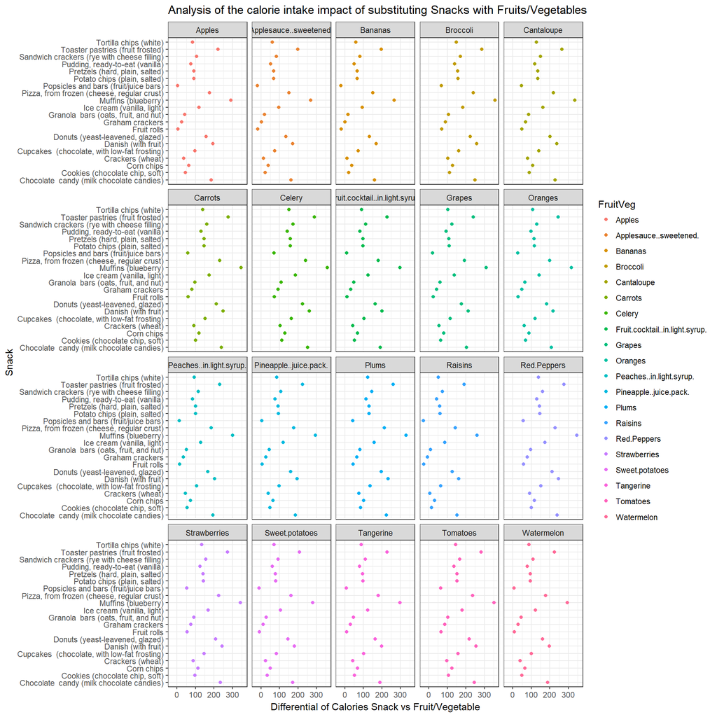

```r
ggplot(calorieimpactfinal, aes(x=DiffCalories, y=Snack, colour = FruitVeg)) + geom_point() + facet_wrap(~FruitVeg) + labs(y = "Snack", x = "Differential of Calories Snack vs Fruit/Vegetable", title = "Analysis of the calorie intake impact of substituting Snacks with Fruits/Vegetables") + theme_bw()
```

###### (Values < 0 mean calorie intake increase due to substitution)

#### Conclusion: With the exception of very few cases like: Sweet Potatoes, Raisins & Apple Sauce, the calorie intake is substantially decreased when substituting Snacks with Fruits/Vegetables

## 2nd Data set - Cost Impact on Snack Substitution

### Load data set (CSV) into R

#### Download target file locally from github “costimpacts (untidy dataset).xls”

```r
setwd("C:/DATA/HHP/Personal/Degrees/Ms. Data Science (CUNY)/R Working Dir")
costimpact_raw <- data.frame(read_excel("costimpacts (untidy dataset).xls", skip = 1, col_names = TRUE))
dim(costimpact_raw)
```

```
## [1] 25 23
```

### Data Wrangling

#### Elminating Headers, Footers and Calculated columns

```r
costimpact_raw <- costimpact_raw[-(22:25),]
costimpact_raw <- costimpact_raw[,-23]
costimpact_raw <- costimpact_raw[-1,]
```

#### Pivoting columns to a key column and Renaming columns

```r
costimpact <- gather(costimpact_raw, "FruitVeg", "DiffCost", 3:22)
names(costimpact) <- c("Snack", "SnackCost", "FruitVeg", "DiffCost")
head(costimpact,22)
```

```
##                    Snack           SnackCost           FruitVeg DiffCost
## 1       Chocolate  candy 0.23999999999999999             Apples    -0.12
## 2                Cookies                0.16             Apples    -0.20
## 3             Corn chips 0.20999999999999999             Apples    -0.15
## 4               Crackers                0.16             Apples    -0.20
## 5               Cupcakes 0.34000000000000002             Apples    -0.02
## 6                 Danish 0.46999999999999997             Apples     0.11
## 7                 Donuts 0.35999999999999999             Apples     0.00
## 8            Fruit rolls 0.28000000000000003             Apples    -0.08
## 9        Graham crackers 0.14000000000000001             Apples    -0.22
## 10         Granola  bars 0.29999999999999999             Apples    -0.06
## 11             Ice cream 0.39000000000000001             Apples     0.03
## 12               Muffins 0.82999999999999996             Apples     0.47
## 13    Pizza, from frozen                0.63             Apples     0.27
## 14    Popsicles and bars 0.34000000000000002             Apples    -0.02
## 15          Potato chips 0.27000000000000002             Apples    -0.09
## 16              Pretzels                0.25             Apples    -0.11
## 17 Pudding, ready-to-eat                0.38             Apples     0.02
## 18     Sandwich crackers 0.20000000000000001             Apples    -0.16
## 19      Toaster pastries 0.34999999999999998             Apples    -0.01
## 20        Tortilla chips 0.20999999999999999             Apples    -0.15
## 21      Chocolate  candy 0.23999999999999999 Applesauce..jarred     0.02
## 22               Cookies                0.16 Applesauce..jarred    -0.06
```

#### Casting data types, creating calculated-columns, arranging column layout

```r
costimpact$SnackCost <- as.numeric(format(costimpact$SnackCost, nsmall = 2))
costimpact$DiffCost <- as.numeric(format(costimpact$DiffCost, nsmall = 2))
costimpact <- mutate(costimpact, FruitVegCost = SnackCost-DiffCost)
totCostchgbyFruitVeg <- summarise(group_by(costimpact, FruitVeg), TotCostChgbyFruitVeg = sum(DiffCost))
costimpact <- costimpact %>% inner_join(totCostchgbyFruitVeg, by = c("FruitVeg"))
costimpactfinal <- select(costimpact, Snack, SnackCost, FruitVeg, FruitVegCost, TotCostChgbyFruitVeg, DiffCost)
head(costimpactfinal,22)
```

```
##                    Snack SnackCost           FruitVeg FruitVegCost
## 1       Chocolate  candy      0.24             Apples         0.36
## 2                Cookies      0.16             Apples         0.36
## 3             Corn chips      0.21             Apples         0.36
## 4               Crackers      0.16             Apples         0.36
## 5               Cupcakes      0.34             Apples         0.36
## 6                 Danish      0.47             Apples         0.36
## 7                 Donuts      0.36             Apples         0.36
## 8            Fruit rolls      0.28             Apples         0.36
## 9        Graham crackers      0.14             Apples         0.36
## 10         Granola  bars      0.30             Apples         0.36
## 11             Ice cream      0.39             Apples         0.36
## 12               Muffins      0.83             Apples         0.36
## 13    Pizza, from frozen      0.63             Apples         0.36
## 14    Popsicles and bars      0.34             Apples         0.36
```

[output cut: 31 more lines]

### Analysis of the cost impact of substituting Snacks with Fruits/Vegetables

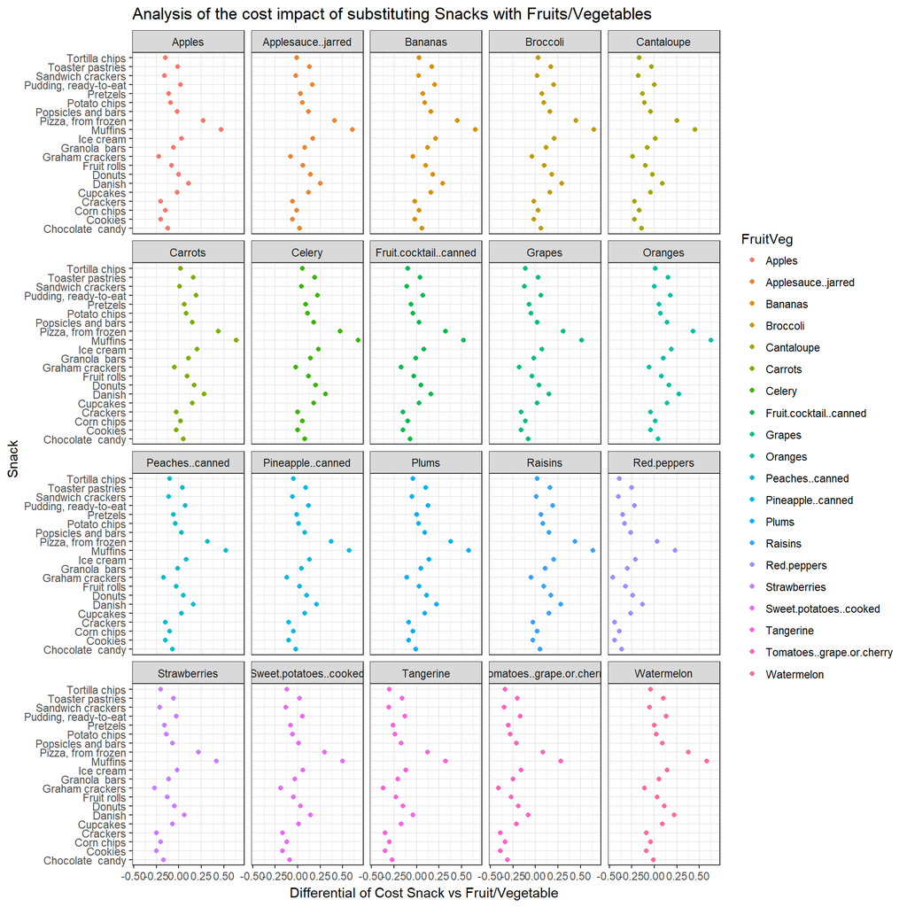

```r
ggplot(costimpactfinal, aes(x=DiffCost, y=Snack, colour = FruitVeg)) + geom_point() + facet_wrap(~FruitVeg)+ labs(y = "Snack", x = "Differential of Cost Snack vs Fruit/Vegetable ",
        title = "Analysis of the cost impact of substituting Snacks with Fruits/Vegetables") + theme_bw()
```

###### (Values < 0 mean cost increase due to subsitution)

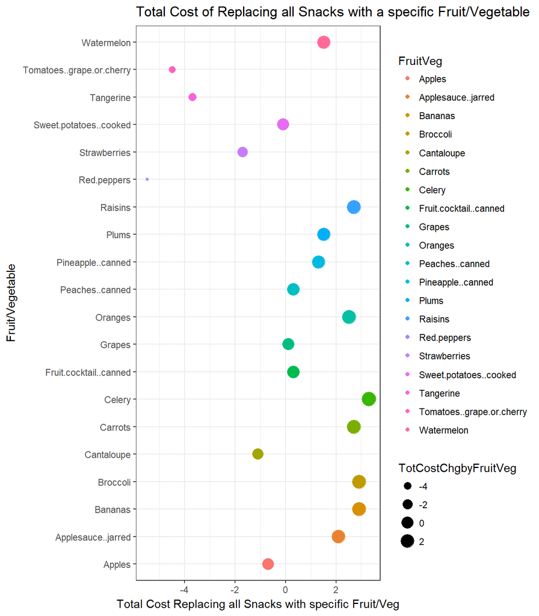

```r
ggplot(costimpactfinal, aes(y = FruitVeg, x = TotCostChgbyFruitVeg)) + geom_point(aes(col=FruitVeg, size=TotCostChgbyFruitVeg)) + labs(y = "Fruit/Vegetable", x = "Total Cost Replacing all Snacks with specific Fruit/Veg",
        title = "Total Cost of Replacing all Snacks with a specific Fruit/Vegetable") + theme_bw()
```

## 3rd Data set - United Nations Migration Data

### Load data set (CSV) into R and eliminate headers

#### Download target file locally from github “UN_MigrantStockByOriginAndDestination_2017.xlsx”

```r
setwd("C:/DATA/HHP/Personal/Degrees/Ms. Data Science (CUNY)/R Working Dir")
migration_raw <- data.frame(read_excel("UN_MigrantStockByOriginAndDestination_2017.xlsx", sheet = "Table 1", skip = 15, col_names = TRUE))
dim(migration_raw)
```

```
## [1] 1917  241
```

```r
head(migration_raw,1)
```

[output not shown]

[output cut: 29 more lines]

[output not shown]

### Data Wrangling

#### Elminating irrelevant columns, including totals

```r
migration_raw <- migration_raw[,-2]
migration_raw <- migration_raw[,-(3:6)]
```

#### Pivoting columns to a key column and Renaming columns

```r
migration <- gather(migration_raw, "CountryOrig", "MigrantStock", 3:236)
names(migration) <- c("Year", "CountryDest", "CountryOrig", "MigrantStock")
head(migration,5)
```

```
##   Year                                                 CountryDest
## 1 1990                                                       WORLD
## 2 1990                                      More developed regions
## 3 1990                                      Less developed regions
## 4 1990                                   Least developed countries
## 5 1990 Less developed regions, excluding least developed countries
##   CountryOrig MigrantStock
## 1 Other.North      2144536
## 2 Other.North      1094823
## 3 Other.North      1049713
## 4 Other.North       250575
## 5 Other.North       799138
```

#### Casting data types and filtering NAs and certain summary categories like: World, Developed, High Income Regions, Continents & Subcontinents, etc.

```r
str(migration)
```

```
## 'data.frame':    448578 obs. of  4 variables:
##  $ Year        : num  1990 1990 1990 1990 1990 1990 1990 1990 1990 1990 ...
##  $ CountryDest : chr  "WORLD" "More developed regions" "Less developed regions" "Least developed countries" ...
##  $ CountryOrig : chr  "Other.North" "Other.North" "Other.North" "Other.North" ...
##  $ MigrantStock: chr  "2144536" "1094823" "1049713" "250575" ...
```

```r
migration$MigrantStock <- as.numeric(migration$MigrantStock)
migration_final <- migration %>% filter(!is.na(MigrantStock))
migration_final <- migration_final %>% filter(!str_detect(CountryDest,"regions|countries|WORLD"))
migration_final <- migration_final %>% filter(!str_detect(CountryDest,"ASIA|AFRICA|EUROPE|LATIN|CARIBBEAN|OCEANIA|Central|Eastern|Western|Southern|Northern|NORTHERN|Other|Sub"))
migration_final <- migration_final %>% filter(!str_detect(CountryOrig,"Other"))
head(migration_final,10)
```

```
##    Year                CountryDest CountryOrig MigrantStock
## 1  1990                      Egypt Afghanistan          237
## 2  1990                      Libya Afghanistan          677
## 3  1990                    Namibia Afghanistan           64
## 4  1990               South Africa Afghanistan           59
## 5  1990                 Tajikistan Afghanistan         8485
## 6  1990                      India Afghanistan        14159
## 7  1990 Iran (Islamic Republic of) Afghanistan      3123968
## 8  1990                   Pakistan Afghanistan      3276673
## 9  1990                   Malaysia Afghanistan           32
## 10 1990                Philippines Afghanistan           25
```

#### Preparing datasets for Ranking Top CountryDest and CountryOrigin by MigrationStock

```r
TopCountryDest <- summarise(group_by(migration_final, CountryDest), MigrantStock=sum(MigrantStock)) %>% arrange(desc(MigrantStock)) %>% head(., 20)
TopCountryOrig <- summarise(group_by(migration_final, CountryOrig), MigrantStock=sum(MigrantStock)) %>% arrange(desc(MigrantStock)) %>% head(., 20)
```

#### Preparing dataset for Migration by CountryDest over time

```r
TopCountryDestOT <- summarise(group_by(migration_final, CountryDest, Year), MigrantStock=sum(MigrantStock)) %>% arrange(desc(MigrantStock)) %>% filter(str_detect(CountryDest,"United States of America|Russia|Germany|Saudi|France|United Kingdom|Canada|Australia|India|New Zealand|Ukraine|United Arab|Pakistan|Italy|Spain|Iran|China"))
```

### Analysis of the Migration Patterns

#### Most Attractive Countries for Immigrants

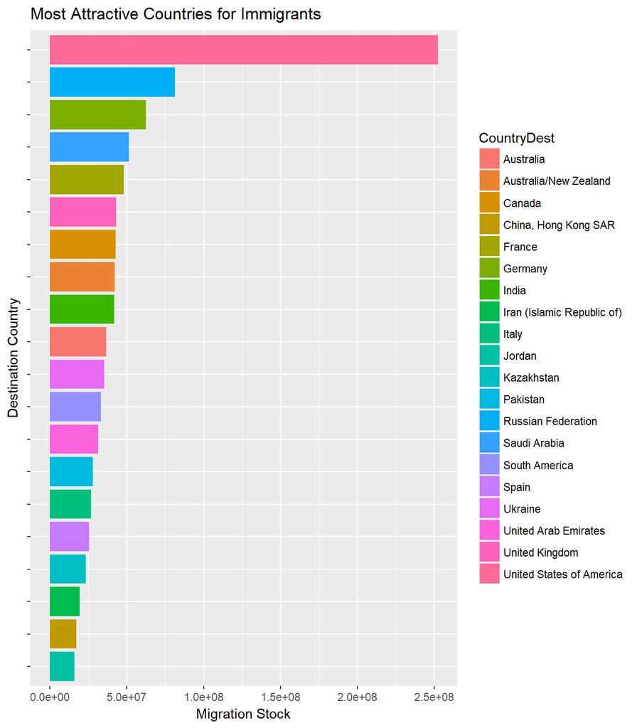

```r
ggplot(TopCountryDest, aes(x=reorder(CountryDest, MigrantStock), y=MigrantStock, fill=CountryDest)) + geom_col(position = "dodge") + coord_flip() + labs(y = "Migration Stock", x = "Destination Country", title = "Most Attractive Countries for Immigrants") + theme(axis.text.y=element_blank())
```

#### Top Countries by # of Migrants

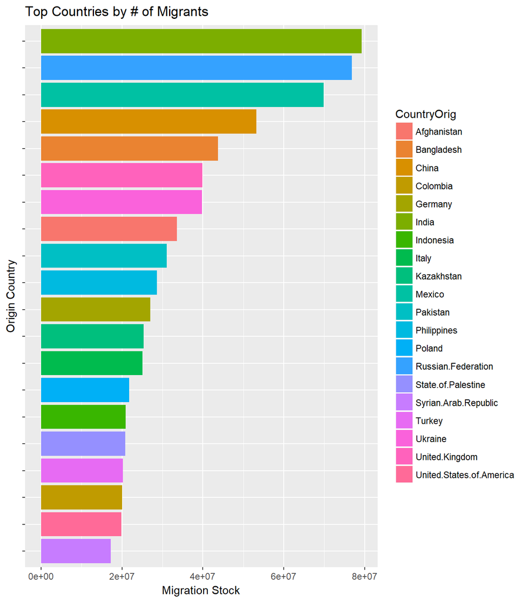

```r
ggplot(TopCountryOrig, aes(x=reorder(CountryOrig, MigrantStock), y=MigrantStock, fill=CountryOrig)) + geom_col(position = "dodge") + coord_flip() + labs(y = "Migration Stock", x = "Origin Country", title = "Top Countries by # of Migrants") + theme(axis.text.y=element_blank())
```

#### MigrationStock over the Years for Top Destination Countries

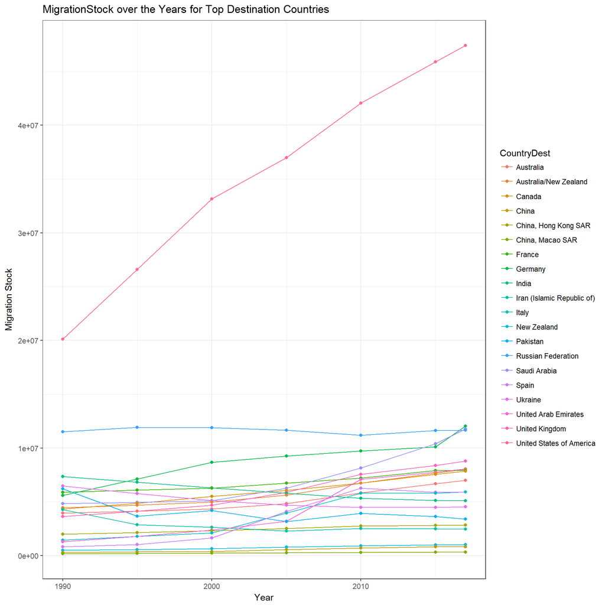

```r
ggplot(TopCountryDestOT, aes(x=Year, y=MigrantStock, group=CountryDest)) + geom_line(aes(color=CountryDest)) + geom_point(aes(color=CountryDest)) + labs(y = "Migration Stock", x = "Year", title = "MigrationStock over the Years for Top Destination Countries") + theme_bw()
```

##### Faceted View

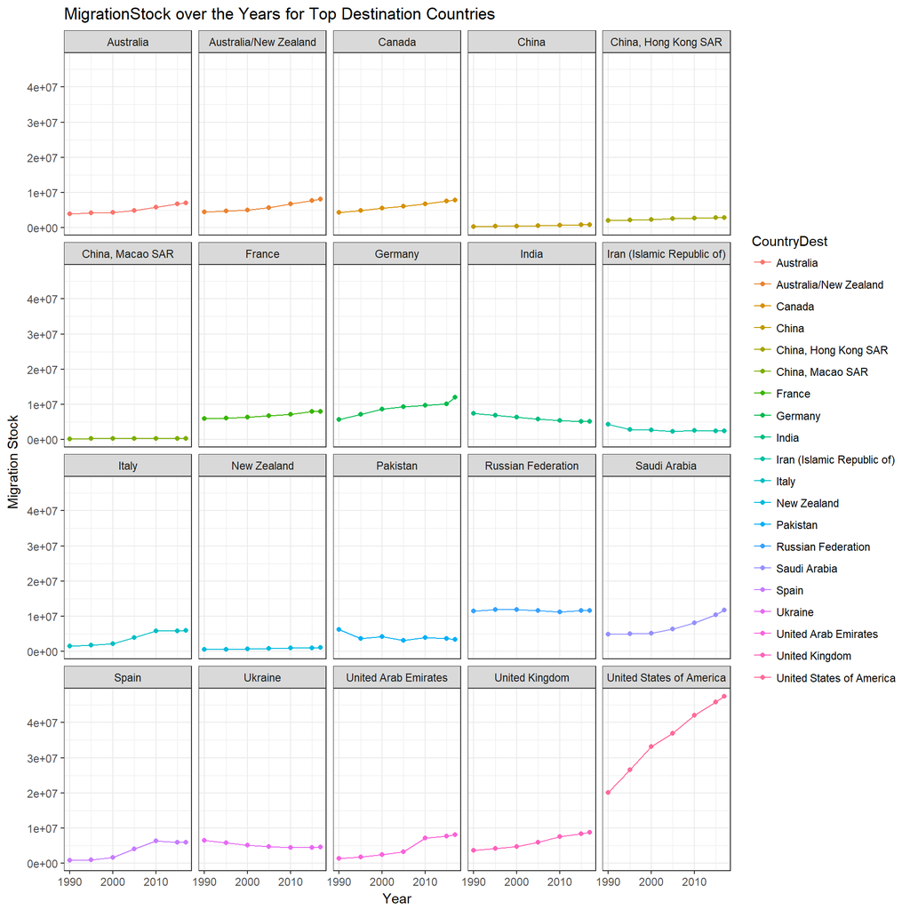

```r
ggplot(TopCountryDestOT, aes(x=Year, y=MigrantStock, group=CountryDest)) + geom_line(aes(color=CountryDest)) + geom_point(aes(color=CountryDest)) + facet_wrap(~CountryDest) + labs(y = "Migration Stock", x = "Year", title = "MigrationStock over the Years for Top Destination Countries") + theme_bw()
```